# Objetivo2

Juanjo

2025-05-05

## 1. Introducción

Este análisis identifica los sectores con huella directa ciudadana (Transporte, Residencial, Gestión de Residuos) y evalúa su impacto en la calidad del aire urbana en ciudades europeas, según el PM2.5 Atlas 2023. Los datos provienen de:

- **gases_city.xlsx**: Contribuciones de gases (NH₃, NMVOC, NOx, PPM25, SOx) por ciudad y sector (GNFR), expresadas como una *Unidad de Impacto Relativo (UIR)*. El UIR es una medida relativa, que representa la contribución de cada gas y sector a las concentraciones de PM2.5, sin normalización a 100%.
- **Ciudades_con_coordenadas.xlsx**: Coordenadas geográficas de ciudades.

El objetivo es agrupar sectores con huella ciudadana, analizar su impacto en la calidad del aire urbana, representarlos en un mapa de Europa y explorar patrones y diferencias regionales, considerando la ubicación geográfica (norte, sur, este, oeste o centro).

## 2. Carga de Librerías y Datos

### 2.1 Instalación y Carga de Librerías

Se cargan las librerías necesarias para la ejecución del código.

```r
library(tidyverse)
library(readxl)
library(ggplot2)
library(leaflet)
library(knitr)
library(plotly)
```

### 2.2 Carga de Datos

Se cargan los archivos Excel y se verifica las filas de cada uno.

```r
gases <- read_excel("gases_city.xlsx")
coords <- read_excel("Ciudades_con_coordenadas.xlsx")

cat("Columnas en gases:", paste(names(gases), collapse = ", "), "\n")
```

```
## Columnas en gases: CIUDAD, SECTOR, GAS, POTENCIAL, ...5, ...6, ...7
```

```r
cat("Filas en gases:", nrow(gases), "\n")
```

```
## Filas en gases: 44820
```

```r
cat("Filas en coords:", nrow(coords), "\n")
```

```
## Filas en coords: 455
```

### 2.3 Limpieza y Preparación

Se estandarizan nombres de ciudades y se mapean los sectores GNFR a nombres descriptivos, seleccionando y separando sectores.

```r
# Estandarizar nombres de ciudades
gases$CIUDAD <- str_to_title(iconv(gases$CIUDAD, to="ASCII//TRANSLIT", sub=""))
coords$City <- str_to_title(iconv(coords$City, to="ASCII//TRANSLIT", sub=""))

# Añadir a cada sector su nombre
sectores_map <- tibble(
  SECTOR = as.character(c(1:12)),
  SECTOR_NOMBRE = c("Public_power", "Industry", "Residencial", "Fugitives", "Solvents",
                    "Road_transportation", "Shipping", "Aviation", "Off_Road_transportation",
                    "Waste", "Agriculture_livestock", "Agriculture_other")
)

# Convertir SECTOR de gases a carácter antes de la unión para asegurarnos de que sean igual
gases$SECTOR <- as.character(gases$SECTOR)
cat("Tipo de datos de gases$SECTOR:", class(gases$SECTOR), "\n")
```

```
## Tipo de datos de gases$SECTOR: character
```

```r
cat("Tipo de datos de sectores_map$SECTOR:", class(sectores_map$SECTOR), "\n")
```

```
## Tipo de datos de sectores_map$SECTOR: character
```

```r
# Agregar nombres de sectores y clasificar en huella ciudadana y no ciudadana
gases_classified <- gases %>%
  left_join(sectores_map, by = "SECTOR") %>%
  mutate(
    SECTOR_AGREGADO = case_when(
      SECTOR %in% c("6", "9") ~ "Transporte",
      SECTOR == "3" ~ "Residencial",
      SECTOR == "10" ~ "Waste",
      TRUE ~ SECTOR_NOMBRE
    ),
    GRUPO = case_when(
      SECTOR_AGREGADO %in% c("Transporte", "Residencial", "Waste") ~ "Con Huella Ciudadana",
      TRUE ~ "Sin Huella Ciudadana"
    )
  ) %>%
  group_by(CIUDAD, SECTOR_AGREGADO, GAS, GRUPO) %>%
  summarise(UIR = sum(POTENCIAL, na.rm = TRUE)) %>%
  ungroup()

# Mostrar número de filas después del filtrado
cat("Filas en gases_classified:", nrow(gases_classified), "\n")
```

```
## Filas en gases_classified: 41085
```

```r
# Unir con datos de coordenadas
data_merged <- gases_classified %>%
  left_join(coords %>% select(City, Country, lat = latitude, lon = longitude), by = c("CIUDAD" = "City"))

# Mostrar número de filas después de la unión
cat("Filas en data_merged después de unión:", nrow(data_merged), "\n")
```

```
## Filas en data_merged después de unión: 41085
```

## 3. Análisis de la Huella Ciudadana

### 3.1 Contribución de Sectores

Se calcula la contribución total (suma) de cada sector a las emisiones de todos los gases (NH₃, NMVOC, NOx, PPM25, SOx), usando un gráfico de barras apiladas para comparar las cantidades totales de cada gas en sectores con y sin huella ciudadana.

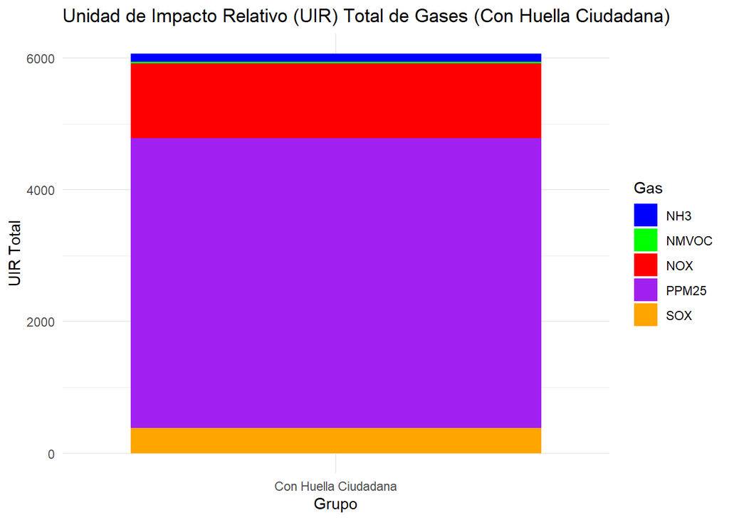

```r
# Estandarizar los nombres de los gases para consistencia
data_merged$GAS <- toupper(trimws(data_merged$GAS))

# Calcular UIR total por sector, gas y grupo (usando suma)
all_emissions <- data_merged %>%
  group_by(GRUPO, GAS) %>%
  summarise(UIR_Total = sum(UIR, na.rm = TRUE)) %>%
  ungroup()


# Gráfico de barras apiladas para sectores con huella ciudadana
p1 <- ggplot(all_emissions %>% filter(GRUPO == "Con Huella Ciudadana"),
             aes(x = GRUPO, y = UIR_Total, fill = GAS)) +
  geom_bar(stat = "identity", position = "stack") +
  labs(title = "Unidad de Impacto Relativo (UIR) Total de Gases (Con Huella Ciudadana)",
       x = "Grupo", y = "UIR Total", fill = "Gas") +
  theme_minimal() +
  scale_fill_manual(values = c("NH3" = "blue", "NMVOC" = "green", "NOX" = "red", "PPM25" = "purple", "SOX" = "orange"))

# Gráfico de barras apiladas para sectores sin huella ciudadana
p2 <- ggplot(all_emissions %>% filter(GRUPO == "Sin Huella Ciudadana"),
             aes(x = GRUPO, y = UIR_Total, fill = GAS)) +
  geom_bar(stat = "identity", position = "stack") +
  labs(title = "Unidad de Impacto Relativo (UIR) Total de Gases (Sin Huella Ciudadana)",
       x = "Grupo", y = "UIR Total", fill = "Gas") +
  theme_minimal() +
  scale_fill_manual(values = c("NH3" = "blue", "NMVOC" = "green", "NOX" = "red", "PPM25" = "purple", "SOX" = "orange"))

# Mostrar ambos gráficos
print(p1)
```

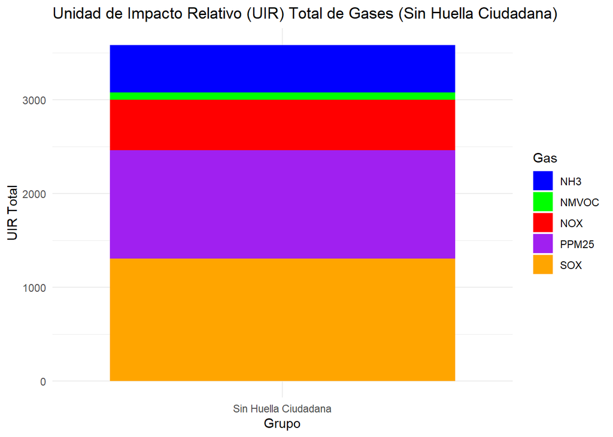

```r
print(p2)
```

Se calcula la contribución total (suma) de cada sector a las emisiones (sumando todos los gases), desglosando por gas dentro de cada sector, y se presentan gráficos interactivos para identificar qué gas contribuye más en cada sector.

```r
# Estandarizar los nombres de los gases para consistencia
data_merged$GAS <- toupper(trimws(data_merged$GAS))

# Calcular UIR total por sector, grupo y gas (usando suma)
sector_emissions <- data_merged %>%
  group_by(GRUPO, SECTOR_AGREGADO, GAS) %>%
  summarise(UIR_Total = sum(UIR, na.rm = TRUE)) %>%
  ungroup()


# Definir colores para los gases
gas_colors <- c("NH3" = "blue", "NMVOC" = "green", "NOX" = "red", "PPM25" = "purple", "SOX" = "orange")

# Gráfico para sectores con huella ciudadana
p1 <- ggplot(sector_emissions %>% filter(GRUPO == "Con Huella Ciudadana"),
               aes(x = SECTOR_AGREGADO, y = UIR_Total, fill = GAS)) +
  geom_bar(stat = "identity", position = "stack") +
  coord_flip() +
  labs(title = "Unidad de Impacto Relativo (UIR) Total por Sector y Gas (Huella Ciudadana)",
       x = "Sector", y = "UIR Total", fill = "Gas") +
  theme_minimal() +
  scale_fill_manual(values = gas_colors)

# Gráfico para sectores sin huella ciudadana
p2 <- ggplot(sector_emissions %>% filter(GRUPO == "Sin Huella Ciudadana"),
             aes(x = SECTOR_AGREGADO, y = UIR_Total, fill = GAS)) +
  geom_bar(stat = "identity", position = "stack") +
  coord_flip() +
  labs(title = "Unidad de Impacto Relativo (UIR) Total por Sector y Gas (Sin Huella Ciudadana)",
       x = "Sector", y = "UIR Total", fill = "Gas") +
  theme_minimal() +
  scale_fill_manual(values = gas_colors)

# Mostrar las gráficas
p1_interactive <- ggplotly(p1, tooltip = c("x", "y", "fill"))
p2_interactive <- ggplotly(p2, tooltip = c("x", "y", "fill"))
print(p1_interactive)
print(p2_interactive)
```

[output not shown]

## 4. Representación Espacial

Se representa espacialmente sobre un mapa de Europa las emisiones totales (sumas) de los sectores con huella ciudadana (Transporte, Residencial, Waste). Al seleccionar una ciudad, se muestra un desplegable con la Unidad de Impacto Relativo (UIR) total de cada gas para estos sectores. Las ciudades se colorean según su Total UIR, simulando un mapa de calor.

```r
# Calcular la suma del UIR por ciudad, sector y gas para sectores con huella ciudadana
base_emissions <- data_merged %>%
  filter(GRUPO == "Con Huella Ciudadana") %>%
  group_by(CIUDAD, Country, SECTOR_AGREGADO, GAS) %>%
  summarise(UIR = sum(UIR, na.rm = TRUE)) %>%
  ungroup()

# Calcular la suma del UIR por sector (sumando las contribuciones de los gases)
total_emissions_by_sector <- base_emissions %>%
  group_by(CIUDAD, Country, SECTOR_AGREGADO) %>%
  summarise(UIR_Total = sum(UIR, na.rm = TRUE)) %>%
  ungroup() %>%
  pivot_wider(names_from = SECTOR_AGREGADO, values_from = UIR_Total, values_fill = 0)

# Calcular la suma total de las contribuciones por sector para cada ciudad
total_by_city <- total_emissions_by_sector %>%
  rowwise() %>%
  mutate(Total_UIR = sum(Transporte, Residencial, Waste, na.rm = TRUE)) %>%
  ungroup()

# Calcular la suma del UIR por gas (sumando las contribuciones de los sectores)
gas_sums_by_city <- base_emissions %>%
  group_by(CIUDAD, Country, GAS) %>%
  summarise(UIR_Total = sum(UIR, na.rm = TRUE)) %>%
  ungroup() %>%
  pivot_wider(names_from = GAS, values_from = UIR_Total, values_fill = 0)

# Unir datos con coordenadas y sumas de gases
map_data <- total_by_city %>%
  left_join(data_merged %>% distinct(CIUDAD, Country, lat, lon), by = c("CIUDAD", "Country")) %>%
  left_join(gas_sums_by_city, by = c("CIUDAD", "Country")) %>%
  filter(!is.na(lat) & !is.na(lon))


# Crear una paleta de colores basada en Total_UIR
pal <- colorNumeric(
  palette = "YlOrRd",  # Paleta de amarillo a rojo
  domain = map_data$Total_UIR
)

leaflet(data = map_data) %>%
  addTiles() %>%
  addCircles(
    lng = ~lon, lat = ~lat, radius = ~Total_UIR * 100,
    color = ~pal(Total_UIR),  # Color basado en Total_UIR
    fillColor = ~pal(Total_UIR),
    fillOpacity = 0.7,
    popup = ~paste(
      "<b>", CIUDAD, "</b><br>",
      "<b>Transporte:</b> ", round(Transporte, 4), " UIR<br>",
      "<b>Residencial:</b> ", round(Residencial, 4), " UIR<br>",
      "<b>Waste:</b> ", round(Waste, 4), " UIR<br>",
      "<b>Total UIR:</b> ", round(Total_UIR, 4), " UIR<br>",
      "<details><summary><b>Unidad de Impacto Relativo (UIR) Total por Gas</b></summary>",
      "<b>NH3:</b> ", round(NH3, 4), " UIR<br>",
      "<b>NMVOC:</b> ", round(NMVOC, 4), " UIR<br>",
      "<b>NOX:</b> ", round(NOX, 4), " UIR<br>",
      "<b>PPM25:</b> ", round(PPM25, 4), " UIR<br>",
      "<b>SOX:</b> ", round(SOX, 4), " UIR</details>"
    )
  ) %>%
  addLegend("bottomright",
            pal = pal,
            values = ~Total_UIR,
            title = "Total UIR",
            opacity = 1)
```

[interactive chart not shown]

## 5. Patrones Comunes y Diferencias Regionales

Se analizan patrones y diferencias regionales en las emisiones de los sectores con huella ciudadana.

### 5.1 Patrones según la Región Geográfica

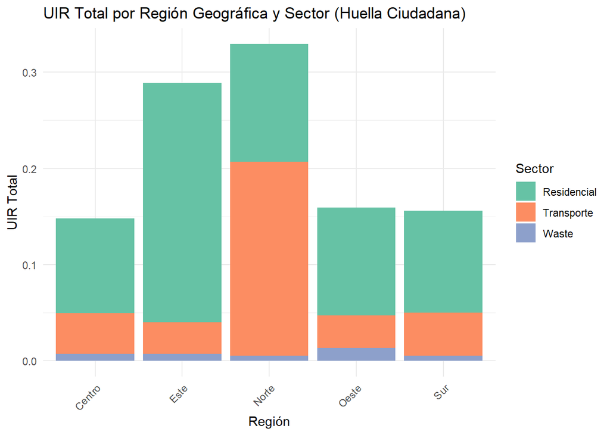

```r
# Clasificar ciudades por región geográfica
regional_data <- total_by_city %>%
  left_join(data_merged %>% distinct(CIUDAD, Country, lat, lon), by = c("CIUDAD", "Country")) %>%
  mutate(
    Region = case_when(
      lat > 55 ~ "Norte",
      lat < 45 ~ "Sur",
      lon > 20 ~ "Este",
      lon < 0 ~ "Oeste",
      between(lat, 45, 55) & between(lon, 0, 20) ~ "Centro",
      TRUE ~ "Desconocida"
    )
  ) %>%
  filter(Region != "Desconocida")

# Calcular UIR total por región y sector
regional_patterns <- base_emissions %>%
  left_join(data_merged %>% distinct(CIUDAD, Country, lat, lon), by = c("CIUDAD", "Country")) %>%
  mutate(
    Region = case_when(
      lat > 55 ~ "Norte",
      lat < 45 ~ "Sur",
      lon > 20 ~ "Este",
      lon < 0 ~ "Oeste",
      between(lat, 45, 55) & between(lon, 0, 20) ~ "Centro",
      TRUE ~ "Desconocida"
    )
  ) %>%
  filter(Region != "Desconocida") %>%
  group_by(Region, SECTOR_AGREGADO) %>%
  summarise(UIR_Total = median(UIR, na.rm = TRUE)) %>%
  ungroup()


# Gráfico de barras apiladas por región y sector
p_region <- ggplot(regional_patterns, aes(x = Region, y = UIR_Total, fill = SECTOR_AGREGADO)) +
  geom_bar(stat = "identity", position = "stack") +
  labs(title = "UIR Total por Región Geográfica y Sector (Huella Ciudadana)",
       x = "Región", y = "UIR Total", fill = "Sector") +
  theme_minimal() +
  scale_fill_brewer(palette = "Set2") +
  theme(axis.text.x = element_text(angle = 45, hjust = 1))

print(p_region)
```

```r
# Seleccionar las 5 ciudades principales por región ordenadas por Total_UIR
top_cities <- regional_data %>%
  group_by(Region) %>%
  arrange(desc(Total_UIR)) %>%
  slice_head(n = 5) %>%
  ungroup() %>%
  select(CIUDAD, Country, Region, Total_UIR)


# Mostrar tabla con las 5 ciudades principales por región
knitr::kable(
  top_cities,
  col.names = c("Ciudad", "País", "Región", "Total UIR"),
  caption = "Top 5 Ciudades por Región según Total UIR",
  digits = 2,
  format = "html"
)
```

Top 5 Ciudades por Región según Total UIR

| Ciudad | País | Región | Total UIR |
| --- | --- | --- | --- |
| Szczecin | Poland | Centro | 35.50 |
| Lodz | Poland | Centro | 34.36 |
| Wroclaw | Poland | Centro | 32.66 |
| Krakow | Poland | Centro | 30.72 |
| Zagreb | Croatia | Centro | 28.57 |
| Warszawa | Poland | Este | 43.71 |
| Vilnius | Lithuania | Este | 36.51 |
| Bialystok | Poland | Este | 32.59 |
| Olsztyn | Poland | Este | 24.28 |
| Kaunas | Lithuania | Este | 23.58 |
| Jyvaskyla | Finland | Norte | 42.70 |
| Trondheim | Norway | Norte | 38.92 |
| Umea | Sweden | Norte | 34.26 |
| Kuopio | Finland | Norte | 33.90 |
| Bergen | Norway | Norte | 33.42 |
| Dublin | Ireland | Oeste | 14.54 |
| Limerick | Ireland | Oeste | 12.92 |
| Nantes | France | Oeste | 11.03 |
| Rennes | France | Oeste | 10.94 |
| Angers | France | Oeste | 10.84 |
| Sofia | Bulgaria | Sur | 43.38 |
| Madrid | Spain | Sur | 41.07 |
| Sevilla | Spain | Sur | 26.96 |
| Bilbao | Spain | Sur | 24.66 |
| Lugo | Spain | Sur | 23.09 |